# Peer Assessment Assignment

GringisimoViejo

December 20, 2015

All analysis below assumes that the working directory has already been set. Since each individual uses a different folder structure and naming convention, it is assumed that the reader has already downloaded the file from [the course web page](https://d396qusza40orc.cloudfront.net/repdata%2Fdata%2Factivity.zip) and added it to his or her working directory.

```r
activity <- read.csv("activity.csv")
library(dplyr)
```

```r
activity2 <- na.omit(activity)
activity2 <- group_by(activity, date)
activity2 <- summarize(activity2, TotalSteps = sum(steps, na.rm = TRUE))
```

A histogram better illustrates the total number of steps taken per day. Notice the large number of days for which there are 0 steps, indicating a possible data quality issue such as the device not being used or not being properly configured.

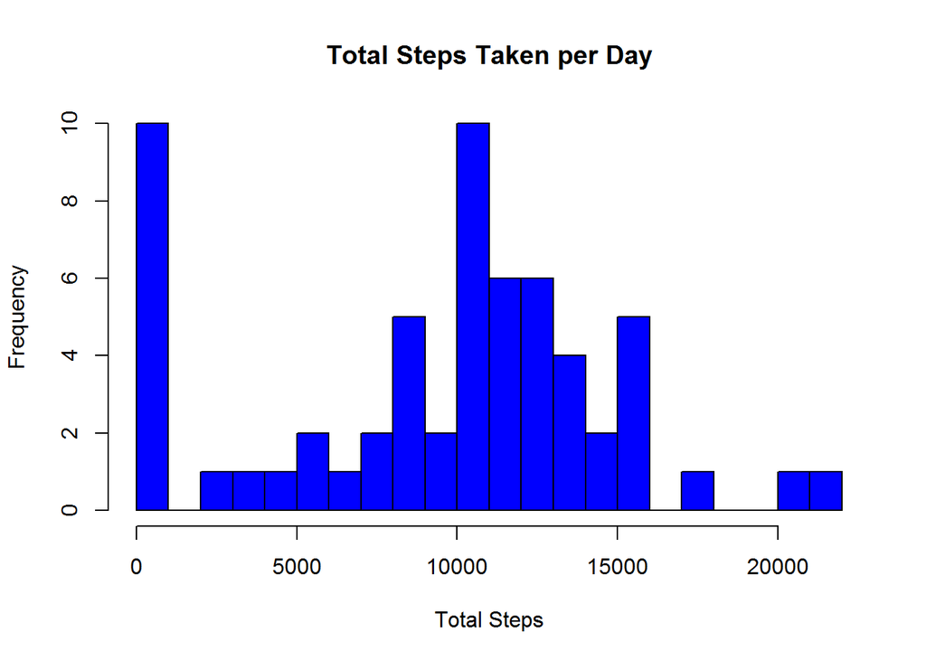

```r
windows()
    hist(activity2$TotalSteps, col = "blue", breaks = 20 ,main = "Total Steps Taken per Day", xlab = "Total Steps")
```

```r
dev.off()
```

```r
mean <- mean(activity2$TotalSteps)
median <- median(activity2$TotalSteps)
```

The mean number of steps taken per day is 9354.2295082 and the median is 10395.

Next, the analysis will examine the number of steps taken per each numbered 5-minute interval of the day. The value used per interval is the mean for that interval across all days of the data set with a time series plot created to better visualize the trends.

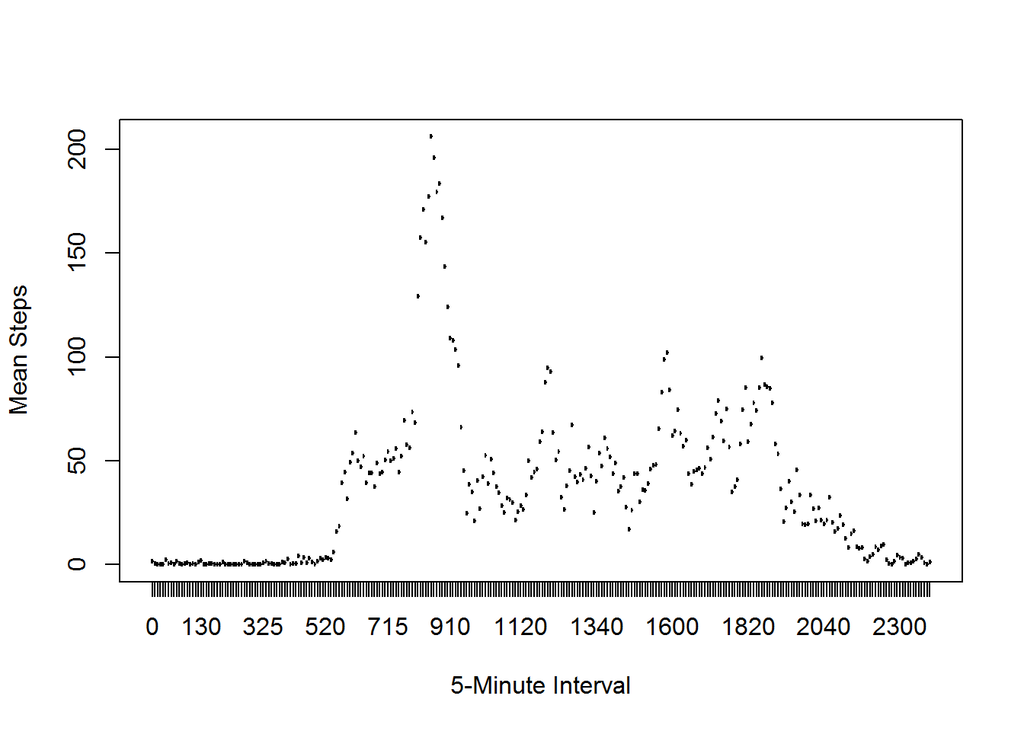

```r
activity3 <- na.omit(activity)
activity3 <- group_by(activity3, interval)
activity3 <- summarize(activity3, MeanSteps = mean(steps, na.rm = TRUE))
activity3$interval <- as.factor(activity3$interval)

windows()
    plot(activity3$interval, activity3$MeanSteps, type = "1", pch = "",
         xlab = "5-Minute Interval", ylab = "Mean Steps")
```

```r
dev.off()
```

Next, the maximum number of mean steps for any one interval is determined.

```r
MaxStepsSub <- activity3
MaxSteps <- max(activity3$MeanSteps)
MaxStepsSub <- subset(activity3, activity3$MeanSteps == MaxSteps)
MaxInterval <- MaxStepsSub$interval
```

The maximum number of steps is 206.1698113 in interval 835.

To revisit the possible data quality issue found on the histogram, the number and percentage of NAs in the data set are calculated.

```r
NumberNA <- sum(is.na(activity$steps))
NotNA <- sum(!is.na(activity$steps))
PercentNA <- (NumberNA / (NumberNA + NotNA)) * 100
```

There are 2304 NAs total in the data set as compared to 15264 valid values, or 13.1147541% of the total values.

To resolve the missing values, NAs were replaced using a new calculation based on that used previously to calculate the mean activity by interval, with that mean activity then substituted in for the NAs.

```r
activity4 <- na.omit(activity)
activity4 <- group_by(activity4, interval)
activity4 <- summarize(activity4, MeanSteps = mean(steps, na.rm = TRUE))
activity5 <- data.frame(activity)
activity5$steps2 <- activity5$steps
ind <- is.na(activity5$steps)
int <- activity5$interval[ind]
activity5$steps2[ind] <- activity4$MeanSteps[match(int, activity4$interval)]
activity6 <- group_by(activity5, date)
activity6 <- summarize(activity6, TotalSteps = sum(steps2))
```

The revised values are reported in this updated histogram. When the NAs are replaced with the mean values for the equivalent intervals in other days, the number of days with zero steps declines from ten to two, but otherwise the distribution looks much like it did before.

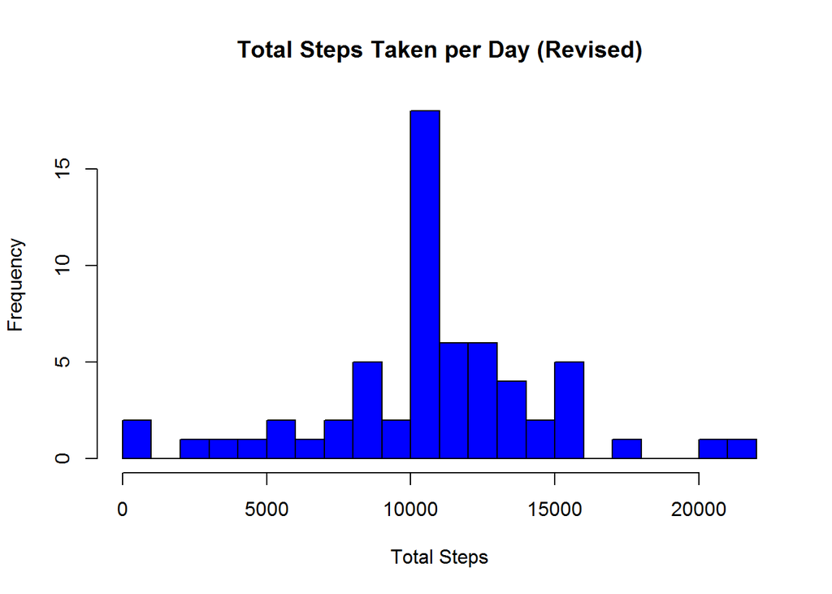

```r
windows()
    hist(activity6$TotalSteps, col = "blue", breaks = 20 ,main = "Total Steps Taken per Day (Revised)", xlab = "Total Steps")
```

```r
dev.off()
```

```r
mean2 <- mean(activity6$TotalSteps)
median2 <- median(activity6$TotalSteps)
```

Next, the days are divided into two levels, Weekday and Weekend, to see if there are any differences between activity at those levels. To conduct this analysis, the levels are defined as Saturday and Sunday comprising the Weekend and the rest of the days comprising the Weekday level.

```r
activity5$day <- weekdays(as.Date(activity5$date))
Weekend <- subset(activity5, activity5$day %in% c("Saturday", "Sunday"))
    Weekend2 <- group_by(Weekend, interval)
    Weekend2 <- summarize(Weekend2, MeanSteps = mean(steps, na.rm = TRUE))
    Weekend2$interval <- as.factor(Weekend2$interval)
Weekday <- subset(activity5, activity5$day %in% c("Monday", "Tuesday", "Wednesday", "Thursday", "Friday"))
    Weekday2 <- group_by(Weekday, interval)
    Weekday2 <- summarize(Weekday2, MeanSteps = mean(steps, na.rm = TRUE))
    Weekday2$interval <- as.factor(Weekday2$interval)
```

A plot is then created to demonstrate the differences between Weekend and Weekday activity levels.

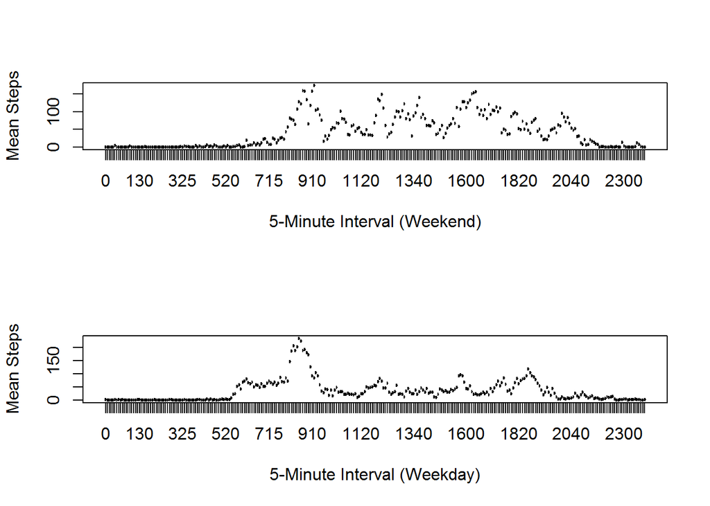

```r
windows()
    par(mfcol = c(2,1))
      plot(Weekend2$interval, Weekend2$MeanSteps, type = "1", pch = "",
          xlab = "5-Minute Interval (Weekend)", ylab = "Mean Steps")
      plot(Weekday2$interval, Weekday2$MeanSteps, type = "1", pch = "",
          xlab = "5-Minute Interval (Weekday)", ylab = "Mean Steps")
```

```r
dev.off()
```